# Wisconsin Evictions Analysis

Rob Wells

7/21/2020

# Analyzing Eviction Court Data From Milwaukee

### Data analysis by Rob Wells

- **The records come from this website**  
  https://wcca.wicourts.gov/advanced.html
- **Part 1: Load Libraries and Data**

Load Data for Evictions tab

```r
july <- rio::import("https://docs.google.com/spreadsheets/d/1RaY8T3ZZb8q0hv8l9eW0Etey8LVlF97AF4a0rEo5khg/edit?pli=1#gid=357722399", which = "July")
```

Load Data for Evictions tab

```r
june <- rio::import("https://docs.google.com/spreadsheets/d/1RaY8T3ZZb8q0hv8l9eW0Etey8LVlF97AF4a0rEo5khg/edit?pli=1#gid=0", which = "June")
```

Load Data for Evictions tab

```r
may <- rio::import("https://docs.google.com/spreadsheets/d/1RaY8T3ZZb8q0hv8l9eW0Etey8LVlF97AF4a0rEo5khg/edit?pli=1#gid=1496576271", which = "May")
```

Load Data for Evictions tab

```r
april <- rio::import("https://docs.google.com/spreadsheets/d/1RaY8T3ZZb8q0hv8l9eW0Etey8LVlF97AF4a0rEo5khg/edit?pli=1#gid=573768668", which = "April")
```

Load Data for Evictions tab

```r
march <- rio::import("https://docs.google.com/spreadsheets/d/1RaY8T3ZZb8q0hv8l9eW0Etey8LVlF97AF4a0rEo5khg/edit?pli=1#gid=1672355376", which = "March")
```

Load Data for Evictions tab

```r
feb <- rio::import("https://docs.google.com/spreadsheets/d/1RaY8T3ZZb8q0hv8l9eW0Etey8LVlF97AF4a0rEo5khg/edit?pli=1#gid=251485342", which = "February")
```

Load Data for Evictions tab

```r
jan <- rio::import("https://docs.google.com/spreadsheets/d/1RaY8T3ZZb8q0hv8l9eW0Etey8LVlF97AF4a0rEo5khg/edit?pli=1#gid=2098662943", which = "January")
```

Combine into single df: 9,500 cases July 6

```r
evict <- rbind(jan, feb, march, april, may, june, july)
```

- **Clean names**

```r
evict <- janitor::clean_names(evict)
```

- **Check data fields**

```r
glimpse(evict)
```

```
## Rows: 9,500
## Columns: 7
## $ case_number   <chr> "2020SC003681", "2020SC003680", "2020SC003676", "2…
## $ filing_date   <chr> "01-30-2020", "01-30-2020", "01-30-2020", "01-30-2…
## $ county_name   <chr> "Milwaukee", "Milwaukee", "Milwaukee", "Milwaukee"…
## $ case_status   <chr> "Closed", "Closed", "Open", "Closed", "Closed", "C…
## $ name          <chr> "Kolbskorner, LLC", "Steimey Enterprises, LLC", "R…
## $ date_of_birth <chr> NA, NA, NA, NA, NA, NA, NA, NA, NA, NA, NA, NA, NA…
## $ caption       <chr> "Kolbskorner, LLC vs. Tanishka Reyes et al", "Stei…
```

- **Process dates**

```r
#Process dates
evict$date <- mdy(evict$filing_date)
evict$year <- year(evict$date)
```

```r
evict <- evict %>%
  mutate(yearmon = format(date, "%Y-%m"))
```

### Total Eviction Filings by Month in Wisconsin

**Wisconsin eviction moratorium was March 27 - May 27, 2020**

```r
z <- evict %>%
  group_by(yearmon) %>%
  count(yearmon)
z
```

```
## # A tibble: 8 x 2
## # Groups:   yearmon [8]
##   yearmon     n
##   <chr>   <int>
## 1 2020-01  2648
## 2 2020-02  2144
## 3 2020-03  1084
## 4 2020-04    54
## 5 2020-05   367
## 6 2020-06  3054
## 7 2020-07   139
## 8 <NA>       10
```

- **Chart of Wisconsin Eviction Filings in 2020**  
  **Wisconsin eviction moratorium was March 27 - May 27, 2020**

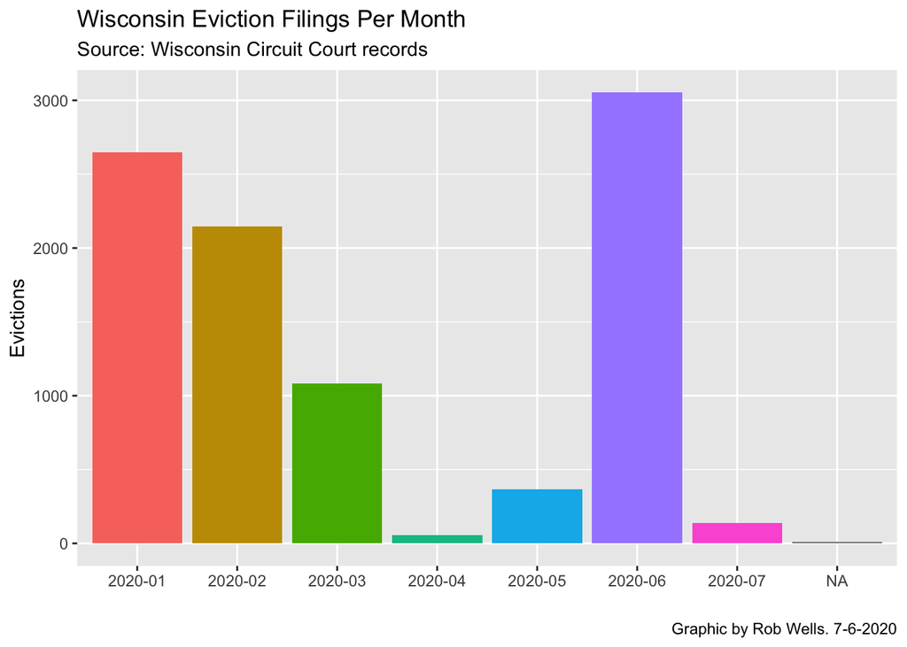

```r
ggplot(z, aes(x=yearmon, y=n, fill=yearmon)) +
  geom_col() +
  labs(title="Wisconsin Eviction Filings Per Month",y="Evictions", x= "",
       caption = "Graphic by Rob Wells. 7-6-2020", subtitle = "Source: Wisconsin Circuit Court records")+
  theme(legend.position="none")
```

```r
ggsave("Wisc_Evict_7_6_2020.png",device = "png",width=9,height=6, dpi=500)
```

– **Evictions by County**

```r
x <- evict %>%
  group_by(county_name) %>%
  count(county_name) %>%
  arrange(desc(n))
head(x)
```

```
## # A tibble: 6 x 2
## # Groups:   county_name [6]
##   county_name     n
##   <chr>       <int>
## 1 Milwaukee    4384
## 2 Dane          623
## 3 Racine        517
## 4 Brown         429
## 5 Winnebago     296
## 6 Kenosha       287
```

– **Milwaukee Subset: 4384 records**

```r
milw <- evict %>%
  filter(county_name == "Milwaukee")
```

– **Milwaukee Eviction Filings by Month**  
**Wisconsin eviction moratorium was March 27 - May 27, 2020**

```r
milw %>%
  group_by(yearmon) %>%
  count(yearmon)
```

```
## # A tibble: 8 x 2
## # Groups:   yearmon [8]
##   yearmon     n
##   <chr>   <int>
## 1 2020-01  1275
## 2 2020-02  1070
## 3 2020-03   433
## 4 2020-04    15
## 5 2020-05    68
## 6 2020-06  1473
## 7 2020-07    49
## 8 <NA>        1
```

– **Chart Milwaukee Eviction Filings by Month**  
**Wisconsin eviction moratorium was March 27 - May 27, 2020**

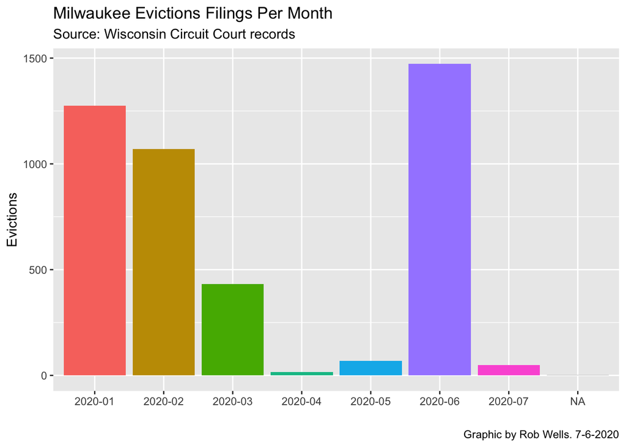

```r
milw %>%
  group_by(yearmon) %>%
  count(yearmon) %>%
  ggplot(aes(x=yearmon, y=n, fill=yearmon)) +
  geom_col() +
  labs(title="Milwaukee Evictions Filings Per Month", y="Evictions", x= "",
       caption = "Graphic by Rob Wells. 7-6-2020", subtitle = "Source: Wisconsin Circuit Court records")+
  theme(legend.position="none")
```

```r
ggsave("Milw_Evict_7_6_2020.png",device = "png",width=9,height=6, dpi=500)
```

- **Check data fields**

```r
glimpse(milw)
```

```
## Rows: 4,384
## Columns: 10
## $ case_number   <chr> "2020SC003681", "2020SC003680", "2020SC003676", "2…
## $ filing_date   <chr> "01-30-2020", "01-30-2020", "01-30-2020", "01-30-2…
## $ county_name   <chr> "Milwaukee", "Milwaukee", "Milwaukee", "Milwaukee"…
## $ case_status   <chr> "Closed", "Closed", "Open", "Closed", "Closed", "C…
## $ name          <chr> "Kolbskorner, LLC", "Steimey Enterprises, LLC", "R…
## $ date_of_birth <chr> NA, NA, NA, NA, NA, NA, NA, NA, NA, NA, NA, NA, NA…
## $ caption       <chr> "Kolbskorner, LLC vs. Tanishka Reyes et al", "Stei…
## $ date          <date> 2020-01-30, 2020-01-30, 2020-01-30, 2020-01-30, 2…
## $ year          <dbl> 2020, 2020, 2020, 2020, 2020, 2020, 2020, 2020, 20…
## $ yearmon       <chr> "2020-01", "2020-01", "2020-01", "2020-01", "2020-…
```

– **Parse Plaintiffs - Defendants in Milwaukee**

```r
milw$parties <- milw$caption

p <- separate(data = milw, col = caption, into = c("plaintiff", "defendant"), sep = " vs. ", extra = "merge", fill = "right")

head(p)
```

```
##    case_number filing_date county_name case_status
## 1 2020SC003681  01-30-2020   Milwaukee      Closed
## 2 2020SC003680  01-30-2020   Milwaukee      Closed
## 3 2020SC003676  01-30-2020   Milwaukee        Open
## 4 2020SC003675  01-30-2020   Milwaukee      Closed
## 5 2020SC003674  01-30-2020   Milwaukee      Closed
## 6 2020SC003673  01-30-2020   Milwaukee      Closed
##                       name date_of_birth                plaintiff
## 1         Kolbskorner, LLC          <NA>         Kolbskorner, LLC
## 2 Steimey Enterprises, LLC          <NA> Steimey Enterprises, LLC
## 3       RYER HOLDINGS, LLC          <NA>       RYER HOLDINGS, LLC
## 4       MCROHR CAPITAL LLC          <NA>       MCROHR CAPITAL LLC
## 5     VEYTSMAN, ANNA-MARIA          <NA>      ANNA-MARIA VEYTSMAN
## 6                 NICD LLC          <NA>                 NICD LLC
##              defendant       date year yearmon
## 1 Tanishka Reyes et al 2020-01-30 2020 2020-01
## 2      Jeffrey Lathrop 2020-01-30 2020 2020-01
## 3    Lasandra Castillo 2020-01-30 2020 2020-01
## 4           John Hardy 2020-01-30 2020 2020-01
## 5  Joel Lundberg et al 2020-01-30 2020 2020-01
## 6   Robert Young et al 2020-01-30 2020 2020-01
##                                        parties
## 1    Kolbskorner, LLC vs. Tanishka Reyes et al
## 2 Steimey Enterprises, LLC vs. Jeffrey Lathrop
## 3     RYER HOLDINGS, LLC vs. Lasandra Castillo
## 4            MCROHR CAPITAL LLC vs. John Hardy
## 5  ANNA-MARIA VEYTSMAN vs. Joel Lundberg et al
## 6              NICD LLC vs. Robert Young et al
```

```r
write.csv(p, "milwevictions.7.6.2020.csv")
```

– **Clean the columns - remove stray spaces**

```r
p$plaintiff <- str_trim(p$plaintiff)
p$defendant <- str_trim(p$defendant)
p$plaintiff <- gsub("[[:punct:]]", "", p$plaintiff)
p$defendant <- gsub("[[:punct:]]", "", p$defendant)
head(p)
```

```
##    case_number filing_date county_name case_status
## 1 2020SC003681  01-30-2020   Milwaukee      Closed
## 2 2020SC003680  01-30-2020   Milwaukee      Closed
## 3 2020SC003676  01-30-2020   Milwaukee        Open
## 4 2020SC003675  01-30-2020   Milwaukee      Closed
## 5 2020SC003674  01-30-2020   Milwaukee      Closed
## 6 2020SC003673  01-30-2020   Milwaukee      Closed
##                       name date_of_birth               plaintiff
## 1         Kolbskorner, LLC          <NA>         Kolbskorner LLC
## 2 Steimey Enterprises, LLC          <NA> Steimey Enterprises LLC
## 3       RYER HOLDINGS, LLC          <NA>       RYER HOLDINGS LLC
## 4       MCROHR CAPITAL LLC          <NA>      MCROHR CAPITAL LLC
## 5     VEYTSMAN, ANNA-MARIA          <NA>      ANNAMARIA VEYTSMAN
## 6                 NICD LLC          <NA>                NICD LLC
##              defendant       date year yearmon
## 1 Tanishka Reyes et al 2020-01-30 2020 2020-01
## 2      Jeffrey Lathrop 2020-01-30 2020 2020-01
## 3    Lasandra Castillo 2020-01-30 2020 2020-01
## 4           John Hardy 2020-01-30 2020 2020-01
## 5  Joel Lundberg et al 2020-01-30 2020 2020-01
## 6   Robert Young et al 2020-01-30 2020 2020-01
##                                        parties
## 1    Kolbskorner, LLC vs. Tanishka Reyes et al
## 2 Steimey Enterprises, LLC vs. Jeffrey Lathrop
## 3     RYER HOLDINGS, LLC vs. Lasandra Castillo
## 4            MCROHR CAPITAL LLC vs. John Hardy
## 5  ANNA-MARIA VEYTSMAN vs. Joel Lundberg et al
## 6              NICD LLC vs. Robert Young et al
```

```r
#x$plaintiff <- gsub(" ", "_", x$plaintiff)
```

– **Summary of Milwaukee Plaintiffs**

```r
#Build a simple summary table
plaintiff1 <- p %>%
  select(plaintiff, defendant, date) %>%
         group_by(plaintiff) %>%
         count(plaintiff) %>%
         ungroup() %>%
         arrange(desc(n))

write.csv(plaintiff1, "milplaintiff.7.6.2020.csv")


plaintiff1
```

```
## # A tibble: 2,031 x 2
##    plaintiff                                   n
##    <chr>                                   <int>
##  1 S2 Real Estate                             81
##  2 Metropolitan Associates                    75
##  3 Berrada Properties 7 LLC                   45
##  4 Falcon Crest LLC                           36
##  5 Guardian Investment Real Estate Company    34
##  6 Daniel W Bruckner                          31
##  7 Gregory W Nawrocki                         27
##  8 Berrada Properties 12 LLC                  25
##  9 Colonial Pointe I Apartments LLC           23
## 10 Meaux Park LLC                             23
## # … with 2,021 more rows
```

–**Radical Cleaning of Plaintiffs** #split data into two columns

```r
p2 <- p

p2$plaintiff_fixed <- p2$plaintiff
```

```r
glimpse(p2)
```

```
## Rows: 4,384
## Columns: 13
## $ case_number     <chr> "2020SC003681", "2020SC003680", "2020SC003676", …
## $ filing_date     <chr> "01-30-2020", "01-30-2020", "01-30-2020", "01-30…
## $ county_name     <chr> "Milwaukee", "Milwaukee", "Milwaukee", "Milwauke…
## $ case_status     <chr> "Closed", "Closed", "Open", "Closed", "Closed", …
## $ name            <chr> "Kolbskorner, LLC", "Steimey Enterprises, LLC", …
## $ date_of_birth   <chr> NA, NA, NA, NA, NA, NA, NA, NA, NA, NA, NA, NA, …
## $ plaintiff       <chr> "Kolbskorner LLC", "Steimey Enterprises LLC", "R…
## $ defendant       <chr> "Tanishka Reyes et al", "Jeffrey Lathrop", "Lasa…
## $ date            <date> 2020-01-30, 2020-01-30, 2020-01-30, 2020-01-30,…
## $ year            <dbl> 2020, 2020, 2020, 2020, 2020, 2020, 2020, 2020, …
## $ yearmon         <chr> "2020-01", "2020-01", "2020-01", "2020-01", "202…
## $ parties         <chr> "Kolbskorner, LLC vs. Tanishka Reyes et al", "St…
## $ plaintiff_fixed <chr> "Kolbskorner LLC", "Steimey Enterprises LLC", "R…
```

```r
p2$plaintiff_fixed <- str_remove(str_replace_all(str_remove(p2$plaintiff_fixed, "^.*\\n"), "\\n", " "), "\\|.*")
```

```r
p2$plaintiff_fixed <- str_trim(p2$plaintiff_fixed)
p2$plaintiff_fixed <- tolower(p2$plaintiff_fixed)
```

–**Substitute top names and normalize**

```r
p2 <- p2 %>%
  mutate(plaintiff_fixed = case_when(plaintiff=="Michael S Wisniewski" ~ "michael_s_wisniewski",
                                     plaintiff=="Daniel W Bruckner" ~ "daniel_w_bruckner",
                                     plaintiff=="Gregory W Nawrocki" ~ "gregory_w_nawrocki",
                                     plaintiff=="Gregory Nawrocki" ~ "gregory_w_nawrocki",
                                     plaintiff=="Gragory W Nawrocki" ~ "gregory_w_nawrocki",
                                     plaintiff=="Gregory W Nawriocki" ~ "gregory_w_nawrocki",
                                     plaintiff=="Bruce Martin" ~ "bruce_martin",
                                     plaintiff=="Housing Authority of the City of Milwaukee" ~ "milwaukee_city_housing_authority",
                                     plaintiff=="City of Milwaukee" ~ "milwaukee_city",
                                     plaintiff=="City  of Milwaukee" ~ "milwaukee_city",
                                     plaintiff=="Paul E. Hurst, C/O Berrada Properties" ~ "berrada",
                                     plaintiff=="Milwaukee Living LLC" ~ "milwaukee_living",
                                     plaintiff=="Milwaukee Capital Properties" ~ "milwaukee_capital",
                                     plaintiff=="Good Hope Townhomes" ~ "good_hope_townhomes",
                                     plaintiff=="Howard and 76th Street Holding Company" ~ "howard_76_st_holding_co",
                                      plaintiff=="Robert J Maas" ~ "robert_maas",
                                    TRUE~plaintiff))
```

–**split names**

```r
p2 <- separate(data = p2, col = plaintiff_fixed, into = c("plaintiff", "plaintiff2", "plaintiff3"), sep = " ", extra = "merge", fill = "right")
```

–**quick total** – **Radical Cleaning - Summary of Milwaukee Plaintiffs**

```r
#Build a simple summary table
plaintiff2 <- p2 %>%
  select(plaintiff, defendant, date) %>%
         group_by(plaintiff) %>%
         count(plaintiff) %>%
         ungroup() %>%
         arrange(desc(n))

write.csv(plaintiff2, "milplaintiff.7.21.2020.csv")
```

–**Top with top 50 Results of Milwaukee Landlords**

```r
plaintiff2 %>%
  top_n(50, n) %>%
  kable() %>%
  kable_styling("striped")
```

| plaintiff | n |
| --- | --- |
| Berrada | 347 |
| TE | 82 |
| S2 | 81 |
| Metropolitan | 75 |
| Northside | 48 |
| Falcon | 36 |
| Colonial | 35 |
| Guardian | 34 |
| milwaukee_city | 33 |
| Spring | 33 |
| daniel_w_bruckner | 31 |
| gregory_w_nawrocki | 31 |
| Robert | 29 |
| Good | 25 |
| Meaux | 23 |
| 3017 | 22 |
| Acme | 22 |
| Anumbera | 22 |
| Milwaukee | 22 |
| Washington | 22 |
| michael_s_wisniewski | 21 |
| Action | 20 |
| howard_76_st_holding_co | 20 |
| Michael | 20 |
| YB | 20 |
| Abuncha | 19 |
| Atunna | 19 |
| DAK | 19 |
| SCV | 19 |
| Atlantis | 18 |
| Blue | 18 |
| bruce_martin | 18 |
| Arbor | 17 |
| Dineen | 17 |
| DLS | 17 |
| MIMG | 17 |
| The | 16 |
| Alotta | 15 |
| Copper | 15 |
| John | 15 |
| Active | 14 |
| Awesome | 14 |
| David | 14 |
| Garden | 14 |
| Garfield | 14 |
| Hivernan | 14 |
| Kilbourn | 14 |
| milwaukee_city_housing_authority | 14 |
| Richard | 14 |
| Sessler | 14 |

–**Note Milwaukee and the city housing authority together have 47 evictions**

– **Radically cleaned summary of Milwaukee Plaintiffs since March 27 2020**

```r
p2 %>%
  filter(date > '2020-03-27') %>%
  select(plaintiff, defendant, date) %>%
         group_by(plaintiff) %>%
         count(plaintiff) %>%
         ungroup() %>%
         arrange(desc(n))
```

```
## # A tibble: 709 x 2
##    plaintiff              n
##    <chr>              <int>
##  1 Berrada              161
##  2 S2                    40
##  3 TE                    35
##  4 daniel_w_bruckner     20
##  5 Metropolitan          18
##  6 gregory_w_nawrocki    17
##  7 Guardian              17
##  8 Robert                17
##  9 Colonial              15
## 10 Falcon                14
## # … with 699 more rows
```

```r
#write.csv(plaintiff1, "milplaintiff.7.6.2020.csv")
```

– **Summary of Milwaukee Defendants**

```r
defendants <- p %>%
  select(plaintiff, defendant, date) %>%
         group_by(defendant) %>%
         count(defendant) %>%
         ungroup() %>%
         arrange(desc(n))
defendants
```

```
## # A tibble: 4,128 x 2
##    defendant                               n
##    <chr>                               <int>
##  1 Party Sealed by Judge Colon18          40
##  2 Party Sealed by Judge Colon18 et al    16
##  3 All Occupants                           5
##  4 Brittany Alvarez                        3
##  5 Chiquita Hill                           3
##  6 Jacqueline Robinson                     3
##  7 Janae Bates                             3
##  8 Kenny Robinson                          3
##  9 Mynora Young                            3
## 10 Adam Lawrence                           2
## # … with 4,118 more rows
```

–**Load PPP data**

```r
ppp <- rio::import("/Users/rswells/Dropbox/Current_Projects/Eviction - Covid Summer 2020/PPP Data/150k plus/foia_150k_plus.xlsx")
```

```r
wiscppp <- ppp %>%
  filter(State=="WI")
```

```r
glimpse(wiscppp)
```

```
## Rows: 12,355
## Columns: 16
## $ LoanRange     <chr> "a $5-10 million", "a $5-10 million", "a $5-10 mil…
## $ BusinessName  <chr> "A LIFE STYLE SERVICE, INC.", "AIR WISCONSIN AIRLI…
## $ Address       <chr> "672 West Washington Avenue", "W6390 Challenger Dr…
## $ City          <chr> "MADISON", "APPLETON", "MENOMONEE FALLS", "SHEBOYG…
## $ State         <chr> "WI", "WI", "WI", "WI", "WI", "WI", "WI", "WI", "W…
## $ Zip           <dbl> 53703, 54914, 53051, 53081, 53051, 54911, 53223, 5…
## $ NAICSCode     <dbl> 561320, 481111, 333318, 339114, 323111, 238210, 33…
## $ BusinessType  <chr> "Corporation", "Limited  Liability Company(LLC)", …
## $ RaceEthnicity <chr> "Unanswered", "Unanswered", "Unanswered", "Unanswe…
## $ Gender        <chr> "Unanswered", "Unanswered", "Unanswered", "Unanswe…
## $ Veteran       <chr> "Unanswered", "Unanswered", "Unanswered", "Unanswe…
## $ NonProfit     <chr> NA, NA, NA, NA, NA, NA, NA, NA, NA, NA, NA, NA, "Y…
## $ JobsRetained  <dbl> 500, 500, 500, 500, 500, 0, 500, 289, 289, 245, 38…
## $ DateApproved  <dttm> 2020-04-28, 2020-04-10, 2020-04-09, 2020-04-15, 2…
## $ Lender        <chr> "BMO Harris Bank National Association", "JPMorgan …
## $ CD            <chr> "WI - 02", "WI - 06", "WI - 04", "WI - 06", "WI - …
```

```r
glimpse(p)
```

```
## Rows: 4,384
## Columns: 12
## $ case_number   <chr> "2020SC003681", "2020SC003680", "2020SC003676", "2…
## $ filing_date   <chr> "01-30-2020", "01-30-2020", "01-30-2020", "01-30-2…
## $ county_name   <chr> "Milwaukee", "Milwaukee", "Milwaukee", "Milwaukee"…
## $ case_status   <chr> "Closed", "Closed", "Open", "Closed", "Closed", "C…
## $ name          <chr> "Kolbskorner, LLC", "Steimey Enterprises, LLC", "R…
## $ date_of_birth <chr> NA, NA, NA, NA, NA, NA, NA, NA, NA, NA, NA, NA, NA…
## $ plaintiff     <chr> "Kolbskorner LLC", "Steimey Enterprises LLC", "RYE…
## $ defendant     <chr> "Tanishka Reyes et al", "Jeffrey Lathrop", "Lasand…
## $ date          <date> 2020-01-30, 2020-01-30, 2020-01-30, 2020-01-30, 2…
## $ year          <dbl> 2020, 2020, 2020, 2020, 2020, 2020, 2020, 2020, 20…
## $ yearmon       <chr> "2020-01", "2020-01", "2020-01", "2020-01", "2020-…
## $ parties       <chr> "Kolbskorner, LLC vs. Tanishka Reyes et al", "Stei…
```

–**30**